# Chapter 10 - Variant Analysis and Genomic Data Interpretation

Sasha Ajay Malkani

2026-01-09

## 1. Variant Analysis and Genomic Data Interpretation

In recent years, the field of genomics has experienced exponential growth, driven by advancements in high-throughput sequencing technologies and the lowering of costs of genomic data generation. As a result, vast amounts of genomic data are now accessible for analysis, with applications spanning from basic research to clinical diagnostics. Variant analysis-determining genetic variants’ significance- is a critical component of genomic studies, especially in understanding disease etiology and therapeutic responses. Un this chapter, we will explore the fundamentals of variant analysis and demonstrate how to interpret genomic data using the R programming language.

### 1. A. Understanding Genetic Variants

Genetic variants are alterations in the nucleotide sequence of DNA that make individuals unique. They occur in various forms, including:

- **Single Nucleotide Polymorphisms (SNPs)**: The most common type of genetic variation, involving a change in a single nucleotide.
- **Insertions and deletions (Indels)**: These variants involve the addition or loss of nucleotides in the genetic sequence.
- **Copy Number Variants (CNVs)**: Variations in the number of copies of a particular gene or genomic region.
- **Structural Variants**: Larger-scale alterations that can affect long segments of DNA.

Understanding these variants’ biological effects and clinical relevance is essential for developing personized medicine strategies and targeted therapies.

### 1. B. R programming for Genomic Analysis

R is powerful environment for statistical computing and graphics, making it a popular choice for data analysis in bioinformatics and genomics. Its comprehensive ecosystem for manipulating, analyzing and visualizing data allows researchers to efficiently interpret complex genomic data sets.

#### 1. B. I. Install and load required packages

To perform variant analysis, several R packages can enhance our workflow. Below are key packages commonly used in genomic data interpretation:

```r
# install.packages(c("BiocManager", "tidyverse"))

# BiocManager::install(c("VariantAnnotation", "GenomicRanges", "biomaRt"))

library(tidyverse)
library(VariantAnnotation)
library(GenomicRanges)
library(biomaRt)
```

#### 1. B. II. Loading Variant Data

Variants can be stored in various formats, such VCF (Variant Call Format). Loading VCF files into R is straightforward with the “VariantsAnnotation” package:

```r
# Loading Exome vcf file
vcf_file <- "D:/Ajay Files/R Programming for Bioinformatics/Chapter 10/Axiom_Exome_Plus.genotypes.all_populations.poly.vcf/Axiom_Exome_Plus.genotypes.all_populations.poly.vcf"
vcf_data <- readVcf(vcf_file, "hg19")
vcf_data
```

```
## class: CollapsedVCF
## dim: 199188 0
## rowRanges(vcf):
##   GRanges with 5 metadata columns: paramRangeID, REF, ALT, QUAL, FILTER
## info(vcf):
##   DataFrame with 6 columns: AC, AF, AN, DB, DP, NS
## info(header(vcf)):
##       Number Type    Description
##    AC A      Integer Allele count in genotypes, for each ALT allele, in the ...
##    AF A      Float   Allele Frequency, for each ALT allele, in the same orde...
##    AN 1      Integer Total number of alleles in called genotypes
##    DB 0      Flag    dbSNP membership, build 135
##    DP 1      Integer Approximate read depth; some reads may have been filtered
##    NS 1      Integer Number of Samples With Data
## geno(vcf):
##   List of length 1: GT
## geno(header(vcf)):
##       Number Type   Description
##    GT 1      String Genotype
```

```r
# Loading Indels vcf file
vcf_file_1 <- "D:/Ajay Files/R Programming for Bioinformatics/Chapter 10/Mills_and_1000G_gold_standard.indels.hg19.sites.txt"
vcf_data_1 <- readVcf(vcf_file_1, "hg19")
vcf_data_1
```

```
## class: CollapsedVCF
## dim: 1274580 0
## rowRanges(vcf):
##   GRanges with 5 metadata columns: paramRangeID, REF, ALT, QUAL, FILTER
## info(vcf):
##   DataFrame with 27 columns: AC, AF, AN, BaseQRankSum, DB, DP, DS, Dels, FS,...
## info(header(vcf)):
##                    Number Type    Description
##    AC              A      Integer Allele count in genotypes, for each ALT al...
##    AF              A      Float   Allele Frequency, for each ALT allele, in ...
##    AN              1      Integer Total number of alleles in called genotypes
##    BaseQRankSum    1      Float   Z-score from Wilcoxon rank sum test of Alt...
##    DB              0      Flag    dbSNP Membership
##    DP              1      Integer Filtered Depth
##    DS              0      Flag    Were any of the samples downsampled?
##    Dels            1      Float   Fraction of Reads Containing Spanning Dele...
##    FS              1      Float   Phred-scaled p-value using Fisher's exact ...
##    HRun            1      Integer Largest Contiguous Homopolymer Run of Vari...
##    HaplotypeScore  1      Float   Consistency of the site with at most two s...
##    InbreedingCoeff 1      Float   Inbreeding coefficient as estimated from t...
##    MQ              1      Float   RMS Mapping Quality
##    MQ0             1      Integer Total Mapping Quality Zero Reads
##    MQRankSum       1      Float   Z-score From Wilcoxon rank sum test of Alt...
##    QD              1      Float   Variant Confidence/Quality by Depth
##    ReadPosRankSum  1      Float   Z-score from Wilcoxon rank sum test of Alt...
##    SB              1      Float   Strand Bias
##    SetBI           0      Flag    SetBI Membership
##    SetCG           0      Flag    SetCG Membership
##    SetDI           0      Flag    SetDI Membership
##    SetML           0      Flag    SetML Membership
##    SetOX           0      Flag    SetOX Membership
##    SetSI           0      Flag    SetSI Membership
##    VQSLOD          1      Float   Log odds ratio of being a true variant ver...
##    culprit         1      String  The annotation which was the worst perform...
##    set             1      String  Source VCF for the merged record in Combin...
## geno(vcf):
##   List of length 5: GT, AD, DP, GQ, PL
## geno(header(vcf)):
##       Number Type    Description
##    GT 1      String  Genotype
##    AD .      Integer Allelic depths for the ref and alt alleles in the order...
##    DP 1      Integer Read Depth (only filtered reads used for calling)
##    GQ 1      Float   Genotype Quality
##    PL G      Integer Normalized, Phred-scaled likelihoods for genotypes as d...
```

```r
# Loading Exome vcf file
vcf_file_2 <- "D:/Ajay Files/R Programming for Bioinformatics/Chapter 10/Mutect2-exome-panel.txt"
vcf_data_2 <- readVcf(vcf_file_2, "hg19")
vcf_data_2
```

```
## class: CollapsedVCF
## dim: 307477 0
## rowRanges(vcf):
##   GRanges with 5 metadata columns: paramRangeID, REF, ALT, QUAL, FILTER
## info(vcf):
##   DataFrame with 1 column: SOMATIC
## info(header(vcf)):
##            Number Type Description
##    SOMATIC 0      Flag somatic
## geno(vcf):
##   List of length 0:
```

#### 1. B. III. Overview of Variant Data Structure

Once the VCF file is loaded, we can inspect its structure. The “vcf_data” object contains important components including the header, sample names, and the genetic variants themselves.

```r
# Inspect VCF data
# summarize(vcf_data) # cannot be used for "CollapsedVCF" object

# Load library
library(dplyr)

# Example: extracting variant info from a VCF object
vcf_df <- data.frame(
  CHROM = as.character(seqnames(rowRanges(vcf_data))),
  POS = start(rowRanges(vcf_data)),
  REF = as.character(ref(vcf_data)),
  ALT = sapply(alt(vcf_data), function(x) paste(as.character(x), collapse=",")),
  QUAL = qual(vcf_data),
  FILTER = filt(vcf_data)
)

dim(vcf_df)
```

```
## [1] 199188      6
```

```r
# Now you can use dplyr's summarise on your data frame
# Example: count variants per chromosome
summary_df <- vcf_df %>%
  group_by(CHROM) %>%
  summarise(variant_count = n(), .groups = 'drop')

head(summary_df)
```

```
## # A tibble: 6 × 2
##   CHROM variant_count
##   <chr>         <int>
## 1 1             20526
## 2 10             7649
## 3 11            12983
## 4 12             9800
## 5 13             3550
## 6 14             6402
```

```r
head(rowRanges(vcf_data))
```

```
## GRanges object with 6 ranges and 5 metadata columns:
##                 seqnames    ranges strand | paramRangeID            REF
##                    <Rle> <IRanges>  <Rle> |     <factor> <DNAStringSet>
##     rs150690004        1     69496      * |           NA              G
##     1:69761_A/T        1     69761      * |           NA              A
##   1:721724_A/AT        1    721724      * |           NA              A
##     rs148989274        1    762485      * |           NA              C
##    1:865545_G/A        1    865545      * |           NA              G
##     rs148711625        1    865584      * |           NA              G
##                                ALT      QUAL      FILTER
##                 <DNAStringSetList> <numeric> <character>
##     rs150690004                  A        NA        PASS
##     1:69761_A/T                  T        NA        PASS
##   1:721724_A/AT                 AT        NA        PASS
##     rs148989274                  A        NA        PASS
##    1:865545_G/A                  A        NA        PASS
##     rs148711625                  A        NA        PASS
##   -------
##   seqinfo: 86 sequences from hg19 genome
```

### 1. C. Analyzing Genetic Variants

#### 1. C. I. Filtering Variants

Before diving into interpretation, it is crucial to filter variants based on predefined criteria, such as quality measures and allele frequency. This ensures that we focus on biologically relevant variants.

```r
# Filter variants based on quality and depth = Zero results
filtered_variants <- vcf_data[info(vcf_data)$QUAL > 30 & rowSums(is.na(geno(vcf_data)$GT)) == 0]
filtered_variants
```

```
## class: CollapsedVCF
## dim: 0 0
## rowRanges(vcf):
##   GRanges with 5 metadata columns: paramRangeID, REF, ALT, QUAL, FILTER
## info(vcf):
##   DataFrame with 6 columns: AC, AF, AN, DB, DP, NS
## info(header(vcf)):
##       Number Type    Description
##    AC A      Integer Allele count in genotypes, for each ALT allele, in the ...
##    AF A      Float   Allele Frequency, for each ALT allele, in the same orde...
##    AN 1      Integer Total number of alleles in called genotypes
##    DB 0      Flag    dbSNP membership, build 135
##    DP 1      Integer Approximate read depth; some reads may have been filtered
##    NS 1      Integer Number of Samples With Data
## geno(vcf):
##   List of length 1: GT
## geno(header(vcf)):
##       Number Type   Description
##    GT 1      String Genotype
```

```r
# Filtering NA's = small data set
filtered_variants <- vcf_data[rowSums(is.na(geno(vcf_data)$GT)) == 0]
filtered_variants
```

```
## class: CollapsedVCF
## dim: 199188 0
## rowRanges(vcf):
##   GRanges with 5 metadata columns: paramRangeID, REF, ALT, QUAL, FILTER
## info(vcf):
##   DataFrame with 6 columns: AC, AF, AN, DB, DP, NS
## info(header(vcf)):
##       Number Type    Description
##    AC A      Integer Allele count in genotypes, for each ALT allele, in the ...
##    AF A      Float   Allele Frequency, for each ALT allele, in the same orde...
##    AN 1      Integer Total number of alleles in called genotypes
##    DB 0      Flag    dbSNP membership, build 135
##    DP 1      Integer Approximate read depth; some reads may have been filtered
##    NS 1      Integer Number of Samples With Data
## geno(vcf):
##   List of length 1: GT
## geno(header(vcf)):
##       Number Type   Description
##    GT 1      String Genotype
```

#### 1. C. II. Variant Annotation

Variant annotation involves adding biological context to the genetic variants, such as gene associations and functional impacts. The “biomaRt” package allows querying the Ensembl database for additional data:

```r
# Annotate variants
variants_df <- as.data.frame(rowRanges(filtered_variants))
mart = useEnsembl('ENSEMBL_MART_ENSEMBL')
mart <- useEnsembl(biomart = "ensembl", dataset = "hsapiens_gene_ensembl")
gene_info <- getBM(attributes = c("external_gene_name", "chromosome_name", "start_position", "end_position"),
                   filters = "chromosomal_region", values = c("1:70000:200000"), mart = mart)
annotated_variants <- merge(variants_df, gene_info, by.x = "seqnames", by.y = "chromosome_name")
```

### 1. D. Visualizing Genomic Data

Visualizing is a powerful tool for interpreting complex genomic data. The “ggplot2” package allows researchers to create informative plots to illustrate the distribution and effects of variants.

#### 1. D. I. Distribution of Variants

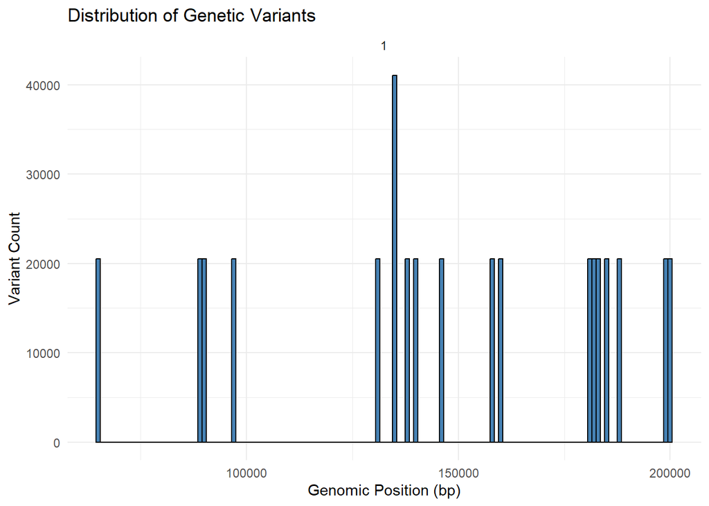

```r
# Plot variant distribution
ggplot(annotated_variants, aes(x = start_position)) +
  geom_histogram(binwidth = 1000, fill = "steelblue", color = "black") +
  facet_wrap(~ seqnames, scales = "free_x") +  # Separate panels for each chromosome
  labs(
    title = "Distribution of Genetic Variants",
    x = "Genomic Position (bp)",
    y = "Variant Count"
  ) +
  theme_minimal()
```

#### 1. D. II. Effect of Variants

Another useful visualization is assessing the effect of variants on specific genes. This can be performed using a boxplot to compare gene expression levels:

```r
# Simulated expression data
# Parameters
set.seed(42)  # reproducibility
n_genes <- 389994   # number of genes
n_samples <- 1     # 2 control, 2 treated
total_counts <- 38999400

# Simulate counts from a negative binomial distribution
raw_counts <- matrix(
  rnbinom(n_genes * n_samples, mu = 50, size = 1/0.2),  # mean=50, dispersion=0.2
  nrow = n_genes,
  ncol = n_samples
)

head(raw_counts)
```

```
##      [,1]
## [1,]   73
## [2,]   38
## [3,]   38
## [4,]   97
## [5,]   96
## [6,]   26
```

```r
# Scale counts so total sum matches exactly 1,013,912
scale_factor <- total_counts / sum(raw_counts)
scale_factor
```

```
## [1] 1.99831
```

```r
counts_scaled <- round(raw_counts * scale_factor)
head(counts_scaled)
```

```
##      [,1]
## [1,]  146
## [2,]   76
## [3,]   76
## [4,]  194
## [5,]  192
## [6,]   52
```

```r
# Assign gene IDs
rownames(counts_scaled) <- paste0("Gene", seq_len(n_genes))
colnames(counts_scaled) <- c("Sample")
head(counts_scaled)
```

```
##       Sample
## Gene1    146
## Gene2     76
## Gene3     76
## Gene4    194
## Gene5    192
## Gene6     52
```

```r
# Write count_scaled matrix to a CSV file (automatic conversion from matrix to data frame)
write.csv(counts_scaled, file = "D:/Ajay Files/R Programming for Bioinformatics/Chapter 10/gene_expression.csv")

# Example: Visualizing Gene Expression Data
gene_expression <- read.csv("gene_expression.csv")
head(gene_expression, n = 1)
```

```
##       X Sample
## 1 Gene1    146
```

```r
# Change X column to Genes
names(gene_expression)[names(gene_expression) == 'X'] <- 'Genes'
head(gene_expression, n = 1)
```

```
##   Genes Sample
## 1 Gene1    146
```

```r
dim(gene_expression)
```

```
## [1] 389994      2
```

```r
# Load Library
library(tidyr)

# Conversion of wide data set to a long data set
gene_expression <- pivot_longer(gene_expression, cols = c("Sample"),
                                names_to = "sample", values_to = "expression_level")
head(gene_expression, n =1)
```

```
## # A tibble: 1 × 3
##   Genes sample expression_level
##   <chr> <chr>             <int>
## 1 Gene1 Sample              146
```

```r
gene_expression <- data.frame(annotated_variants,
                              Expression_Level = gene_expression$expression_level)
head(gene_expression, n = 3)
```

```
##   seqnames   start     end width strand paramRangeID REF ALT QUAL FILTER
## 1        1 1686116 1686116     1      *         <NA>   C   T   NA   PASS
## 2        1 1686116 1686116     1      *         <NA>   C   T   NA   PASS
## 3        1 1686116 1686116     1      *         <NA>   C   T   NA   PASS
##   external_gene_name start_position end_position Expression_Level
## 1              OR4F5          65419        71585              146
## 2                             89295       181719               76
## 3                             89551        91105               76
```

[figure not shown]

```r
# Assuming expression_levels is a data frame with gene expression data

boxplot_data <- gene_expression

ggplot(boxplot_data,
       aes(x = external_gene_name, y = Expression_Level, fill = REF)) +
  geom_boxplot() +
  labs(title = "Gene Expression by Variant Effect", x = "Gene", y = "Expression Level")
```

Variant analysis and interpretation are integral to unlocking the secrets hidden within genomic data, Through the advanced capabilities of R and its bioinformatics packages, researchers can analyze, annotate, and visualize variants to derive meaningful conclusions. As the field continues to evolve, mastering these data interpretation technique will be essential for anyone seeking to harness the power of genomics in research or clinical settings.

### 1. E. Further Reading

For readers interested in deepening their understanding of variant analysis using R, we recommend the following resources:

- **“Bioconductor: The R/Bioconductor ecosystem for genomic data analysis”** - an excellent resource for genomic data analysis with R.
- **“R programming for Bioinformatics” by Robert Gentleman** - this book provides a comprehensive introduction to using R in the context of bioinformatics.

With the foundations laid in this chapter, you are now equipped to explore and interpret genomic data using R efficiently.

### 1. F. Conclusion

In this chapter, we have covered the essentials of variant analysis and genomic data interpretation using R. We delved into understanding different types of genetic variants, how to load and filter VCF data, the importance of variant annotation, and the power of visualization for data interpretation.

## 2. Calling and Annotating Variants using VariantAnnotation.

In modern bioinformatics, the detection and annotation of genetic variants are pivotal for understanding the genetic basis of diseases, population genomics, and personalized medicine. With the advent of next-generation sequencing (NGS), variant calling and subsequent annotation have become routine steps in the genomic analysis pipeline. R, a versatile programming language and environment, provides powerful packages for handling bioinformatics data, among which the “VariantAnnotation” package stands out. This chapter will guide you through the process of calling and annotating variants using “VariantAnnotation” in R, equipping you with skills needed to analyze genomic variants effectively.

### 2. A. Installing and Loading the VariantAnnotation Package.

Before diving into variant calling and annotation, ensure that you have the “VariantAnnotation” package installed in your R environment. You can easily install it from Bioconductor by executing the folowing commands:

```r
# if (!require("BiocManager", quietly = TRUE))
#   install.packages("BiocManager")
# BiocManager::install(version = "3.22")

# BiocManager::install(c("VariantAnnotation"))

# Once installed, load the package along with other necessary libraries:

library(VariantAnnotation)
library(GenomicRanges)
library(dplyr)
library(ggplot2) # For visualization if needed
```

### 2. B. Importing Variant Calling Format (VCF) Files

Variant Call Format (VCF) files serve as common data structure for storing variant data. VCF files contain important information regarding the position and type of variants, along with other annotations. To import a VCF file into R, use the “readVcf()” function:

```r
# Loading Indels vcf file
vcf_file_1 <- "D:/Ajay Files/R Programming for Bioinformatics/Chapter 10/Mills_and_1000G_gold_standard.indels.hg19.sites.txt"
vcf_data_1 <- readVcf(vcf_file_1, "hg19") # Replace "hg19" with your reference genome
```

After loading the VCF file, it’s crucial to explore its structure for further analysis:

#### 2. B. I. Explore Structure

```r
head(vcf_data_1)
```

```
## class: CollapsedVCF
## dim: 6 0
## rowRanges(vcf):
##   GRanges with 5 metadata columns: paramRangeID, REF, ALT, QUAL, FILTER
## info(vcf):
##   DataFrame with 27 columns: AC, AF, AN, BaseQRankSum, DB, DP, DS, Dels, FS,...
## info(header(vcf)):
##                    Number Type    Description
##    AC              A      Integer Allele count in genotypes, for each ALT al...
##    AF              A      Float   Allele Frequency, for each ALT allele, in ...
##    AN              1      Integer Total number of alleles in called genotypes
##    BaseQRankSum    1      Float   Z-score from Wilcoxon rank sum test of Alt...
##    DB              0      Flag    dbSNP Membership
##    DP              1      Integer Filtered Depth
##    DS              0      Flag    Were any of the samples downsampled?
##    Dels            1      Float   Fraction of Reads Containing Spanning Dele...
##    FS              1      Float   Phred-scaled p-value using Fisher's exact ...
##    HRun            1      Integer Largest Contiguous Homopolymer Run of Vari...
##    HaplotypeScore  1      Float   Consistency of the site with at most two s...
##    InbreedingCoeff 1      Float   Inbreeding coefficient as estimated from t...
##    MQ              1      Float   RMS Mapping Quality
##    MQ0             1      Integer Total Mapping Quality Zero Reads
##    MQRankSum       1      Float   Z-score From Wilcoxon rank sum test of Alt...
##    QD              1      Float   Variant Confidence/Quality by Depth
##    ReadPosRankSum  1      Float   Z-score from Wilcoxon rank sum test of Alt...
##    SB              1      Float   Strand Bias
##    SetBI           0      Flag    SetBI Membership
##    SetCG           0      Flag    SetCG Membership
##    SetDI           0      Flag    SetDI Membership
##    SetML           0      Flag    SetML Membership
##    SetOX           0      Flag    SetOX Membership
##    SetSI           0      Flag    SetSI Membership
##    VQSLOD          1      Float   Log odds ratio of being a true variant ver...
##    culprit         1      String  The annotation which was the worst perform...
##    set             1      String  Source VCF for the merged record in Combin...
## geno(vcf):
##   List of length 5: GT, AD, DP, GQ, PL
## geno(header(vcf)):
##       Number Type    Description
##    GT 1      String  Genotype
##    AD .      Integer Allelic depths for the ref and alt alleles in the order...
##    DP 1      Integer Read Depth (only filtered reads used for calling)
##    GQ 1      Float   Genotype Quality
##    PL G      Integer Normalized, Phred-scaled likelihoods for genotypes as d...
```

### 2. C. Understanding the VCF Structure

A VCF file consists of a header and a body. The header contains metadata and format definitions, while the body includes the actual variant calls. Key columns you’ll find in VCF format include:

- **CHROM:** chromosome
- **POS:** position
- **ID:** variant identifier
- **REF:** reference allele
- **ALT:** alternate allele
- **QUAL:** quality score
- **FILTER:** filter status
- **INFO:** additional annotations

Familiarizing yourself with these fields will help you utilize the “Variant Annotation” functions effectively.

### 2. D. Variant Calling

Variant calling typically involves identifying differences between sequenced genomes and the reference genome. While “VarinatAnnotation” does not perform variant calling by itself, it provides tools for manipulating the results obtained from variant callers such as GATK, FreeBayes, or SAMtools. The key functions include filtering and sub-setting variants based on specific criteria.

To filter variants based on quality score, for instance, you would use:

```r
dim(vcf_data_1)
```

```
## [1] 1274580       0
```

```r
filtered_variants <- vcf_data_1[info(vcf_data_1)$QUAL >= 30]
head(filtered_variants)
```

```
## class: CollapsedVCF
## dim: 0 0
## rowRanges(vcf):
##   GRanges with 5 metadata columns: paramRangeID, REF, ALT, QUAL, FILTER
## info(vcf):
##   DataFrame with 27 columns: AC, AF, AN, BaseQRankSum, DB, DP, DS, Dels, FS,...
## info(header(vcf)):
##                    Number Type    Description
##    AC              A      Integer Allele count in genotypes, for each ALT al...
##    AF              A      Float   Allele Frequency, for each ALT allele, in ...
##    AN              1      Integer Total number of alleles in called genotypes
##    BaseQRankSum    1      Float   Z-score from Wilcoxon rank sum test of Alt...
##    DB              0      Flag    dbSNP Membership
##    DP              1      Integer Filtered Depth
##    DS              0      Flag    Were any of the samples downsampled?
##    Dels            1      Float   Fraction of Reads Containing Spanning Dele...
##    FS              1      Float   Phred-scaled p-value using Fisher's exact ...
##    HRun            1      Integer Largest Contiguous Homopolymer Run of Vari...
##    HaplotypeScore  1      Float   Consistency of the site with at most two s...
##    InbreedingCoeff 1      Float   Inbreeding coefficient as estimated from t...
##    MQ              1      Float   RMS Mapping Quality
##    MQ0             1      Integer Total Mapping Quality Zero Reads
##    MQRankSum       1      Float   Z-score From Wilcoxon rank sum test of Alt...
##    QD              1      Float   Variant Confidence/Quality by Depth
##    ReadPosRankSum  1      Float   Z-score from Wilcoxon rank sum test of Alt...
##    SB              1      Float   Strand Bias
##    SetBI           0      Flag    SetBI Membership
##    SetCG           0      Flag    SetCG Membership
##    SetDI           0      Flag    SetDI Membership
##    SetML           0      Flag    SetML Membership
##    SetOX           0      Flag    SetOX Membership
##    SetSI           0      Flag    SetSI Membership
##    VQSLOD          1      Float   Log odds ratio of being a true variant ver...
##    culprit         1      String  The annotation which was the worst perform...
##    set             1      String  Source VCF for the merged record in Combin...
## geno(vcf):
##   List of length 5: GT, AD, DP, GQ, PL
## geno(header(vcf)):
##       Number Type    Description
##    GT 1      String  Genotype
##    AD .      Integer Allelic depths for the ref and alt alleles in the order...
##    DP 1      Integer Read Depth (only filtered reads used for calling)
##    GQ 1      Float   Genotype Quality
##    PL G      Integer Normalized, Phred-scaled likelihoods for genotypes as d...
```

```r
dim(filtered_variants)
```

```
## [1] 0 0
```

### 2. E. Annotating Variants

Variant annotation enriches your data with biological context, linking variants to genes, pathways, and clinical significance. The “VariantAnnotation” package provides essential functions to annotate variants with data from external resources.

#### 2. E. I. Using the “annovar” or “dbSNP” Database for Annotation.

To annotate variants, you can use databases like ANNOVAR or dbSNP. Below is an example of how you might approach integrating dbSNP data:

```r
# Install Packages
# BiocManager::install("txdbmaker")
# BiocManager::install("RMariaDB")
# BiocManager::install("GenomeInfoDbData")

# Load Packages
library(VariantAnnotation)
library(GenomicFeatures)
library(AnnotationDbi)
library(org.Hs.eg.db)
library(txdbmaker)
library(RMariaDB)
library(GenomeInfoDbData)

# Example of annotating with dbSNP

# Read your VCF into a single data frame or data.table from the start
vcf_file <- "D:/Ajay Files/R Programming for Bioinformatics/Chapter 10/Mutect2-exome-panel.txt"

# Read VCF
vcf <- readVcf(vcf_file, "hg19")
vcf
```

```
## class: CollapsedVCF
## dim: 307477 0
## rowRanges(vcf):
##   GRanges with 5 metadata columns: paramRangeID, REF, ALT, QUAL, FILTER
## info(vcf):
##   DataFrame with 1 column: SOMATIC
## info(header(vcf)):
##            Number Type Description
##    SOMATIC 0      Flag somatic
## geno(vcf):
##   List of length 0:
```

```r
# Convert to data.frame
vcf_df <- as.data.frame(rowRanges(vcf))
head(vcf_df)
```

```
##             seqnames start   end width strand paramRangeID REF ALT QUAL FILTER
## 1:13380_C/G        1 13380 13380     1      *         <NA>   C   G   NA   PASS
## 1:13395_T/C        1 13395 13395     1      *         <NA>   T   C   NA   PASS
## 1:13418_G/A        1 13418 13418     1      *         <NA>   G   A   NA   PASS
## 1:13494_A/G        1 13494 13494     1      *         <NA>   A   G   NA   PASS
## 1:13504_G/A        1 13504 13504     1      *         <NA>   G   A   NA   PASS
## 1:13525_G/T        1 13525 13525     1      *         <NA>   G   T   NA   PASS
```

```r
# vcf_df is not a pure data frame of atomic vectors convert to a proper data frame
# Flatten list columns to character
vcf_df_flat <- data.frame(lapply(vcf_df, function(col) {
  if (is.list(col)) {
    sapply(col, function(x) paste(x, collapse = ","))  # join list elements
  } else {
    col
  }
}), stringsAsFactors = FALSE)

# Write vcf_df dataframe to a CSV file
write.csv(vcf_df_flat, file = "D:/Ajay Files/R Programming for Bioinformatics/Chapter 10/vcf_df.csv")

# Example: annotate with transcript database
txdb <- makeTxDbFromUCSC(genome = "hg19", tablename = "refGene")
```

```
## Download the refGene table ...
```

```
## OK
```

```
## Download the hgFixed.refLink table ... OK
## Extract the 'transcripts' data frame ... OK
## Extract the 'splicings' data frame ...
```

[output not shown]

[output cut: 35 more lines]

[output not shown]

```
## OK
## Download and preprocess the 'chrominfo' data frame ... OK
## Prepare the 'metadata' data frame ... OK
## Make the TxDb object ...
```

```
## OK
```

```r
# Annotate
annotations <- locateVariants(rowRanges(vcf), txdb, AllVariants())
head(annotations)
```

```
## GRanges object with 0 ranges and 9 metadata columns:
##    seqnames    ranges strand | LOCATION  LOCSTART    LOCEND   QUERYID      TXID
##       <Rle> <IRanges>  <Rle> | <factor> <integer> <integer> <integer> <integer>
##            CDSID      GENEID       PRECEDEID        FOLLOWID
##    <IntegerList> <character> <CharacterList> <CharacterList>
##   -------
##   seqinfo: no sequences
```

#### 2. E. II. Adding Gene Annotations

To include additional gene annotations, leverage the “TxDb” package, which contains comprehensive gene information. Build a transcript database and annotate your VCF as follows:

```r
# Install Package
# BiocManager::install("TxDb.Hsapiens.UCSC.hg19.knownGene")

# Load Libraries
library(TxDb.Hsapiens.UCSC.hg19.knownGene)
library(GenomicFeatures)

# Assign the TxDb object to a variable
txdb <- TxDb.Hsapiens.UCSC.hg19.knownGene

# Extract genomic ranges for all genes
gr <- genes(txdb)
```

```
##   24 genes were dropped because they have exons located on both strands of the
##   same reference sequence or on more than one reference sequence, so cannot be
##   represented by a single genomic range.
##   Use 'single.strand.genes.only=FALSE' to get all the genes in a GRangesList
##   object, or use suppressMessages() to suppress this message.
```

```r
# Inspect the first few entries
head(gr)
```

```
## GRanges object with 6 ranges and 1 metadata column:
##             seqnames              ranges strand |     gene_id
##                <Rle>           <IRanges>  <Rle> | <character>
##           1    chr19   58856544-58874117      - |           1
##          10     chr8   18248792-18258728      + |          10
##         100    chr20   43213537-43280893      - |         100
##        1000    chr18   25512843-25757910      - |        1000
##       10000     chr1 243651535-244014381      - |       10000
##   100008586     chrX   49315881-49332821      + |   100008586
##   -------
##   seqinfo: 298 sequences (2 circular) from hg19 genome
```

What’s happening here:

- TxDb.Hsapiens.UCSC.hg19.knownGene is a pre-built transcript database for the human genome (hg19 build).
- genes(txdb) returns a GRanges object where each row represents a gene’s genomic coordinates (chromosome, start, end, strand).
- The mcols(gr) will contain the gene IDs (Entrez IDs in this case).

If you want to link these to gene symbols (more human-readable names), you can do:

```r
# Map Entrez IDs to gene symbols
gene_symbols <- mapIds(org.Hs.eg.db,
                       keys = as.character(gr$gene_id),
                       column = "SYMBOL",
                       keytype = "ENTREZID",
                       multiVals = "first")
mcols(gr)$symbol <- gene_symbols

head(gr)
```

```
## GRanges object with 6 ranges and 2 metadata columns:
##             seqnames              ranges strand |     gene_id      symbol
##                <Rle>           <IRanges>  <Rle> | <character> <character>
##           1    chr19   58856544-58874117      - |           1        A1BG
##          10     chr8   18248792-18258728      + |          10        NAT2
##         100    chr20   43213537-43280893      - |         100         ADA
##        1000    chr18   25512843-25757910      - |        1000        CDH2
##       10000     chr1 243651535-244014381      - |       10000        AKT3
##   100008586     chrX   49315881-49332821      + |   100008586     GAGE12F
##   -------
##   seqinfo: 298 sequences (2 circular) from hg19 genome
```

```r
# Read your table-based VCF
# Example: columns = CHR, POS, REF, ALT
vcf_df <- read.csv("vcf_df.csv", header = TRUE)
head(vcf_df)
```

```
##   X seqnames start   end width strand paramRangeID REF ALT QUAL FILTER
## 1 1        1 13380 13380     1      *           NA   C   G   NA   PASS
## 2 2        1 13395 13395     1      *           NA   T   C   NA   PASS
## 3 3        1 13418 13418     1      *           NA   G   A   NA   PASS
## 4 4        1 13494 13494     1      *           NA   A   G   NA   PASS
## 5 5        1 13504 13504     1      *           NA   G   A   NA   PASS
## 6 6        1 13525 13525     1      *           NA   G   T   NA   PASS
```

```r
# Create GRanges from your table
vcf_gr <- GRanges(
  seqnames = vcf_df$seqnames,  # or vcf_df$seqnames if that's your column name
  ranges = IRanges(start = vcf_df$start, end = vcf_df$end)
)

# Add REF and ALT as metadata columns
mcols(vcf_gr)$REF <- vcf_df$REF
mcols(vcf_gr)$ALT <- vcf_df$ALT

head(vcf_gr)
```

```
## GRanges object with 6 ranges and 2 metadata columns:
##       seqnames    ranges strand |         REF         ALT
##          <Rle> <IRanges>  <Rle> | <character> <character>
##   [1]        1     13380      * |           C           G
##   [2]        1     13395      * |           T           C
##   [3]        1     13418      * |           G           A
##   [4]        1     13494      * |           A           G
##   [5]        1     13504      * |           G           A
##   [6]        1     13525      * |           G           T
##   -------
##   seqinfo: 25 sequences from an unspecified genome; no seqlengths
```

```r
# Ensure chromosome naming style matches
library(GenomeInfoDb)
seqlevelsStyle(vcf_gr) <- seqlevelsStyle(gr)

# Find overlaps
hits <- findOverlaps(vcf_gr, gr)

# Create annotated variant table
variant_gene_df <- data.frame(
  chr = as.character(seqnames(vcf_gr)[queryHits(hits)]),
  pos = start(vcf_gr)[queryHits(hits)],
  ref = mcols(vcf_gr)$REF[queryHits(hits)],
  alt = mcols(vcf_gr)$ALT[queryHits(hits)],
  gene_id = gr$gene_id[subjectHits(hits)],
  gene_symbol = gr$symbol[subjectHits(hits)]
)

# View results
head(variant_gene_df)
```

```
##    chr   pos ref alt   gene_id gene_symbol
## 1 chr1 13380   C   G 100287102     DDX11L1
## 2 chr1 13395   T   C 100287102     DDX11L1
## 3 chr1 13418   G   A 100287102     DDX11L1
## 4 chr1 13494   A   G 100287102     DDX11L1
## 5 chr1 13504   G   A 100287102     DDX11L1
## 6 chr1 13525   G   T 100287102     DDX11L1
```

### 2. F. Visualizing Variants

Visualization plays a crucial role in understanding varinat distributions and their implications. You can create plots to visualize the frequency of variants across different genomic regions utilizing “ggplot2”.

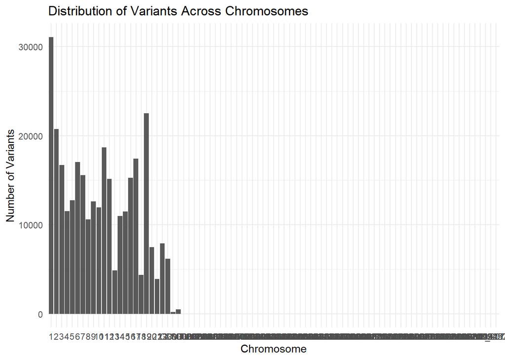

```r
variant_counts <- data.frame(table(seqnames(vcf)))
colnames(variant_counts) <- c("Chromosome", "VariantCount")

library(ggplot2)

ggplot(variant_counts, aes(x = Chromosome, y = VariantCount)) +
  geom_bar(stat = "identity") +
  theme_minimal() +
  labs(title = "Distribution of Variants Across Chromosomes", x = "Chromosome",
       y = "Number of Variants")
```

### 2. G. Exporting the Results

After calling and annotating variants, it’s essential to save your results for further analysis. Use the “writeVcf()” function to export your annotated VCF. **Better to write the annotated variant file to a CSV**.

```r
# Write variant_gene_df to a CSV file using write.csv
output_file <- "D:/Ajay Files/R Programming for Bioinformatics/Chapter 10/variant_gene_df.csv"
write.csv(variant_gene_df, file = output_file)
```

In this chapter, we explored the fundamental steps involved in calling and annotating variants using the “VariantAnnotation” package in R. We covered importing annotations, and visualizing the data for comprehensive analysis

## 3. Exploring SNPs, Indels, and Their Biological Impact.

Understanding these variations provides insight into evolutionary mechanisms, disease susceptibility, and the development of targeted therapies. This chapter delves into the methodologies for identifying and analyzing SNPs and indels, employing the R programming language for data exploration, visualization, and biological interpretation.

### 3. A. Understanding SNPs and Indels

#### 3. A. I. SNPs: Definition and Significance

SNPs are variations at a single nucleotide position in the genome, where different individuals may have different nucleotides (e.g. A, T, C or G). These variations can affect gene function, regulation or expression, contributing to phenotypic diversity. Their significance extends beyond individual traits, as SNPs can serve as biomarkers for diseases, influence drug response, and inform about population structure.

#### 3. A. II. Indels: Definition and Biological Relevance.

Indels refer to insertions and deletions of small segments of DNA, which can range from a single nucleotide to several base pairs. Like SNPs, indels can disrupt gene function and contribute to genetic diversity. Their impact on the genome can lead to frameshifts in coding sequences, altering protein structures and functions, thereby playing a crucial role in evolution and adaptation.

### 3. B. Data Acquistion and Preparation.

Before analyzing SNPs and indels, researchers must obtain suitable genomic datasets. This section covers approaches for retriving genomic data from public repositories, such as the Genome Aggregation Database (gnomAD), the 1000 Genomes Project, and Ensembl.

#### 3. B. I. Installing Required Packages in R.

The following R packages are essential for data analysis and visualization:

```r
# Install Packages
# install.packages(c("tidyverse", "Biostrings", "ggplot2", "GenomicRanges",
#                    "VariantAnnotation"))
```

#### 3. B. II. Importing Genomic Data

Using the “VariantAnnotation” package, genomic data can be read into R:

```r
# Load Library
library(VariantAnnotation)

# Loading Exome vcf file
vcf_file_2 <- "D:/Ajay Files/R Programming for Bioinformatics/Chapter 10/Mutect2-exome-panel.txt"
vcf_data_2 <- readVcf(vcf_file_2, "hg19")
vcf_data_2
```

```
## class: CollapsedVCF
## dim: 307477 0
## rowRanges(vcf):
##   GRanges with 5 metadata columns: paramRangeID, REF, ALT, QUAL, FILTER
## info(vcf):
##   DataFrame with 1 column: SOMATIC
## info(header(vcf)):
##            Number Type Description
##    SOMATIC 0      Flag somatic
## geno(vcf):
##   List of length 0:
```

### 3. C. Data Preprocessing

After loading the data, it is crucial to preprocess it - filtering for quality, selecting relevant columns, and transforming formats where necessary. For example, we can convert VCF data to a more manageable data frame format:

```r
snp_data <-as.data.frame(info(vcf_data_2))
head(snp_data)
```

```
##             SOMATIC
## 1:13380_C/G    TRUE
## 1:13395_T/C    TRUE
## 1:13418_G/A    TRUE
## 1:13494_A/G    TRUE
## 1:13504_G/A    TRUE
## 1:13525_G/T    TRUE
```

```r
snp_df <- as.data.frame(rowRanges(vcf_data_2))
head(snp_df)
```

```
##             seqnames start   end width strand paramRangeID REF ALT QUAL FILTER
## 1:13380_C/G        1 13380 13380     1      *         <NA>   C   G   NA   PASS
## 1:13395_T/C        1 13395 13395     1      *         <NA>   T   C   NA   PASS
## 1:13418_G/A        1 13418 13418     1      *         <NA>   G   A   NA   PASS
## 1:13494_A/G        1 13494 13494     1      *         <NA>   A   G   NA   PASS
## 1:13504_G/A        1 13504 13504     1      *         <NA>   G   A   NA   PASS
## 1:13525_G/T        1 13525 13525     1      *         <NA>   G   T   NA   PASS
```

### 3. D. Visualizing SNPs and Indels

Effective visualization helps in interpreting complex data. In this section, we utilize “ggplot2” for visual exploration.

#### 3. D. I. Plotting SNP Distribution

To visualize the distrubution of SNPs across the genome:

[figure not shown]

```r
# Load Library
library(ggplot2)

ggplot(snp_df, aes(x = start, fill = as.factor(REF))) + geom_bar() +
  labs(title = "SNP Distribtution Across the Genome", x = "Position", y = "Count") +
  theme_minimal()
```

#### 3. D. II. Visualizing Indel Frequency

In a similar manner, plots can be generated to reveal the frequency of indels:

```r
# Load Library
library(VariantAnnotation)

# Loading Indels vcf file
vcf_file_1 <- "D:/Ajay Files/R Programming for Bioinformatics/Chapter 10/Mills_and_1000G_gold_standard.indels.hg19.sites.txt"
vcf_data_1 <- readVcf(vcf_file_1, "hg19")
vcf_data_1
```

```
## class: CollapsedVCF
## dim: 1274580 0
## rowRanges(vcf):
##   GRanges with 5 metadata columns: paramRangeID, REF, ALT, QUAL, FILTER
## info(vcf):
##   DataFrame with 27 columns: AC, AF, AN, BaseQRankSum, DB, DP, DS, Dels, FS,...
## info(header(vcf)):
##                    Number Type    Description
##    AC              A      Integer Allele count in genotypes, for each ALT al...
##    AF              A      Float   Allele Frequency, for each ALT allele, in ...
##    AN              1      Integer Total number of alleles in called genotypes
##    BaseQRankSum    1      Float   Z-score from Wilcoxon rank sum test of Alt...
##    DB              0      Flag    dbSNP Membership
##    DP              1      Integer Filtered Depth
##    DS              0      Flag    Were any of the samples downsampled?
##    Dels            1      Float   Fraction of Reads Containing Spanning Dele...
##    FS              1      Float   Phred-scaled p-value using Fisher's exact ...
##    HRun            1      Integer Largest Contiguous Homopolymer Run of Vari...
##    HaplotypeScore  1      Float   Consistency of the site with at most two s...
##    InbreedingCoeff 1      Float   Inbreeding coefficient as estimated from t...
##    MQ              1      Float   RMS Mapping Quality
##    MQ0             1      Integer Total Mapping Quality Zero Reads
##    MQRankSum       1      Float   Z-score From Wilcoxon rank sum test of Alt...
##    QD              1      Float   Variant Confidence/Quality by Depth
##    ReadPosRankSum  1      Float   Z-score from Wilcoxon rank sum test of Alt...
##    SB              1      Float   Strand Bias
##    SetBI           0      Flag    SetBI Membership
##    SetCG           0      Flag    SetCG Membership
##    SetDI           0      Flag    SetDI Membership
##    SetML           0      Flag    SetML Membership
##    SetOX           0      Flag    SetOX Membership
##    SetSI           0      Flag    SetSI Membership
##    VQSLOD          1      Float   Log odds ratio of being a true variant ver...
##    culprit         1      String  The annotation which was the worst perform...
##    set             1      String  Source VCF for the merged record in Combin...
## geno(vcf):
##   List of length 5: GT, AD, DP, GQ, PL
## geno(header(vcf)):
##       Number Type    Description
##    GT 1      String  Genotype
##    AD .      Integer Allelic depths for the ref and alt alleles in the order...
##    DP 1      Integer Read Depth (only filtered reads used for calling)
##    GQ 1      Float   Genotype Quality
##    PL G      Integer Normalized, Phred-scaled likelihoods for genotypes as d...
```

```r
# Remove duplicate
# Extract GRanges from VCF
rr <- rowRanges(vcf_data_1)

# Make the names unique
names(rr) <- make.unique(names(rr))

# Convert rr to data frame
indel_df <- as.data.frame(rr)
head(indel_df)
```

```
##                     seqnames  start    end width strand paramRangeID   REF
## chr1:55249_C/CTATGG     chr1  55249  55249     1      *         <NA>     C
## chr1:87114_CT/C         chr1  87114  87115     2      *         <NA>    CT
## chr1:233586_CCT/C       chr1 233586 233588     3      *         <NA>   CCT
## chr1:691567_CACAG/C     chr1 691567 691571     5      *         <NA> CACAG
## chr1:715309_AG/A        chr1 715309 715310     2      *         <NA>    AG
## chr1:722074_A/ATT       chr1 722074 722074     1      *         <NA>     A
##                        ALT    QUAL FILTER
## chr1:55249_C/CTATGG CTATGG 6160.83   PASS
## chr1:87114_CT/C          C  666.86   PASS
## chr1:233586_CCT/C        C 1083.97   PASS
## chr1:691567_CACAG/C      C 2260.77   PASS
## chr1:715309_AG/A         A  108.86   PASS
## chr1:722074_A/ATT      ATT  361.06   PASS
```

```r
# Dataset too large to produce the graph
# ggplot(indel_df, aes(x = start, fill = as.factor(REF))) + geom_bar() +
#   labs(title = "Indel Frequency Distribution", x = "Position", y = "Count") +
#   theme_minimal()
```

### 3. E. Analyzing Biological Impact

The biological implications of SNPs and indels are immense, influencing gene function and disease predisposition. This section outlines methods for assessing their effects.

#### 3. E. I. Functional Annotation

Using Bioconductor tools, one can perform functional annotation to predict the impact of genetic variants. For instance, we can leverage dbSNP and the Ensembl Variant Effect Predictor.

#### 3. E. II. Association Studies

To investigate SNP associations with phenotypic traits or diseases, various statistical tests can be conducted, such as Chi-square tests or logistic regression models.

```r
# Chi-square test example
# variant_counts <- table(snp_data$PHENOTYPE, snp_data$GENOTYPE)
# chisq.test(variant_counts)
```

#### 3. E. III. Pathway Analysis

Advanced analyses can include pathway enrichment analysis to determine if significant variants cluster in specific biological pathways, potentially shedding light on mechanisms underlying diseases.

```r
Sys.Date()
```

```
## [1] "2026-01-18"
```